# Do Returns Have Trends, Long Memory, Autocorrelation and Cycles? : Evidence from Markets of Different Financial Products and Regions

Stats 531 Midterm Project

# 1 Introduction

In this study, we explore several kinds of financial times series by adopting various time series techniques covered in class such as SARIMA, parameter estimation, spectral analysis, and extra techniques such as estimating Hurst parameter to give some statistical, mathematical and financial explanations for empirical phenomena.

## 1.1 Raising Questions

In the class, we found that the absolute value of centered returns of S&P500 times series is correlated$^{[1]}$. A series of questions about this interests me a lot. Is the normal distribution model really fit the log returns? How are the log returns correlated? Do log returns have cycles or seasonality? How to model them if they are correlated? If the market is not efficient, can we statistical arbitrage on them? Do other kinds of assets have cycles? After being confused by these questions, I read papers first to see how predecessors deal with these problems.

## 1.2 Literature Reviews

Financial stock indexes log returns are observed to have less autocorrelation when the markets become more mature$^{[2]}$. They have more or less long term memory$^{[3]}$ which can be modeled by ARMA model or ARFIMA model. The distribution of log returns are poorly modeled by normal distribution and have a heavier tail$^{[4]}$.To better model the log returns’ long memory property and heavy tail, we no longer assume the independent of log returns. Fractional Brownian motion is introduced and can describe these properties well$^{[5]}$. We will estimate the Hurst parameter of fractional Brownian motion in modelling the log returns. Futures have some common properties as equity$^{[6]}$ and later we will see the spot and futures relationship and try to find seasonality of fitted residuals and explore the arbitrage opportunity. Spectral analysis after smoothing can help us read the cycles more clearly$^{[7]}$. Moreover, there exist seasonality in some spot-futures spread$^{[8]}$.

# 2 Introduction of Data

The S&P500 Index and futures data I analyzed is the close value and last price of S&P500 Index and futures from Jan 1st 2000 to Feb 23th, 2018. The data is downloaded from Factset at Tozzi Financial Trading Center, Ross School of Business, University of Michigan. The HangSeng Index and futures, CSI 300 Index and futures and Shanghai Stock Exchange reverse repurchase interest rate GC001(retRevRepo) are from the same source with different starting date but all end Feb 23th, 2018.

First we load and take a look at the data. We are quite familiar with the exponential increasing graph of S&P500 index in the class so we directly get the log returns and see the ACF of square of log returns.

```r
SP500Index=read.table(file="https://raw.githubusercontent.com/RickYuankangHung/Quant-python/master/SP500PriceHistory.csv")
lretSP500Index=diff(log((array(rev(as.numeric(as.character(SP500Index[,1])))))))
date=seq(from=1,to=length(lretSP500Index),by=1)

VSP500Index=rev(array((as.numeric(as.character(SP500Index[,1])))))

SP500FuturesIndex=read.table(file="https://raw.githubusercontent.com/RickYuankangHung/Quant-python/master/S%26P500CMEContinuousPriceHistory.csv")
VSP500FuturesIndex=rev(array((as.numeric(as.character(SP500FuturesIndex[,1])))))

revrepo=read.csv(file="https://raw.githubusercontent.com/RickYuankangHung/Quant-python/master/revrepo.csv")
retRevRepo=rev(revrepo[,3]/100)
```

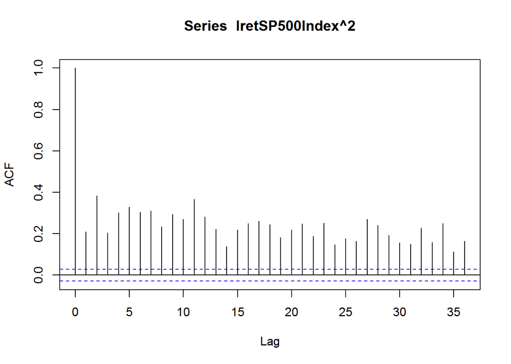

```r
acf(lretSP500Index^2)
```

We can see the square of log returns are highly correlated. If we use a band pass filter to see the log returns.

## 2.1 Detecting Trend and Cycles by Band Pass Filter

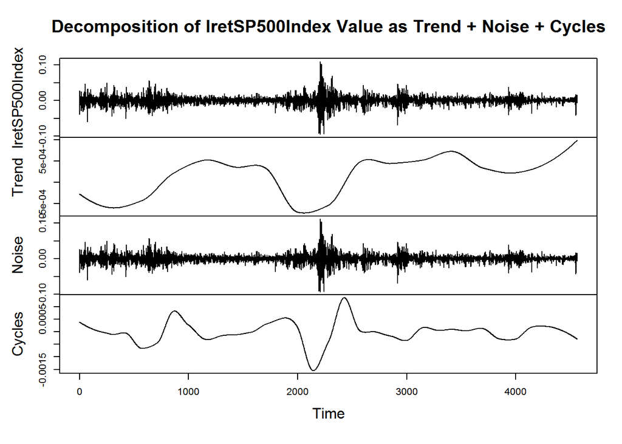

```r
lretSP500Index_low = ts(loess(lretSP500Index ~ as.numeric(date),span=0.35,frequency=252)$fitted)
Trend = lretSP500Index_low
lretSP500Index_hi = ts(lretSP500Index - loess(lretSP500Index ~ as.numeric(date),span=0.16,frequency=252)$fitted)
Noise = lretSP500Index_hi
lretSP500Index_cycles=lretSP500Index - lretSP500Index_hi - lretSP500Index_low
Cycles = lretSP500Index_cycles
plot(ts.union(lretSP500Index, Trend, Noise, Cycles), type = "l", main = "Decomposition of lretSP500Index Value as Trend + Noise + Cycles")
```

We find the noise is not stationary while the cycles are obvious and the trend’s magnitude is small. The log returns of the index may be better modeled by the fractional Brownian motion which allows for autocorrelation and long memory. First we try ARIMA model for log index.

## 2.2 ARIMA Model of log Index

```r
arima_SP=arima(log(VSP500Index),order=c(5,1,5))
arima_SP
```

```
##
## Call:
## arima(x = log(VSP500Index), order = c(5, 1, 5))
##
## Coefficients:
##           ar1      ar2      ar3      ar4     ar5     ma1     ma2     ma3
##       -0.8575  -0.2572  -0.7195  -0.0123  0.4087  0.7794  0.1400  0.6702
## s.e.   0.2156   0.2575   0.1722   0.1753  0.2817  0.2066  0.2495  0.1542
##           ma4      ma5
##       -0.0621  -0.4958
## s.e.   0.1598   0.2622
##
## sigma^2 estimated as 0.000145:  log likelihood = 13693.63,  aic = -27365.26
```

It seems just as what we saw in the AIC graph in the lecture that there should be a significant lag one term. We can also use another model to capture the violation of efficient market hypothesis( if we do not consider the transaction cost).

# 3 Estimating the Hurst Parameter of Fractional Brownian Motion

## 3.1 Mathematical Model Specification

In probability theory, fractional Brownian motion $(fBm)$, also called a fractal Brownian motion, is a generalization of Brownian motion. Unlike classical Brownian motion, the increments of $fBm$ need not be independent. $fBm$ is a continuous-time Gaussian process $B_H(t)$ on $[0, T]$, which starts at zero, has expectation zero for all $t$ in $[0, T]$, and has the following covariance function$^{[9]}$:
$$\begin{aligned}
E[B_{H}(t)B_{H}(s)]=\frac{1}{2}(|t|^{2H}+|s|^{2H}-|t-s|^{2H})
\end{aligned}$$
where $H$ is a real number in $(0, 1)$, called the Hurst index or Hurst parameter associated with the fractional Brownian motion. The Hurst exponent describes the raggedness of the resultant motion, with a higher value leading to a smoother motion. The value of H determines what kind of process the fBm is: if H = 1/2 then the process is in fact a Brownian motion or Wiener process; if H > 1/2 then the increments of the process are positively correlated; if H < 1/2 then the increments of the process are negatively correlated.

## 3.2 Statistical Estimation Procedure

In the following sections, I will use R/S method to evaluate the Hurst parameter.
Considering the time series
$$X^*_j (j=1,..,N)$$
We divide the time series into $K^u$ non-overlapping blocks of length $d^u=\frac{N}{K^u}$
And we fix:
$$t_i=d^u(i-1)+1$$
Next we get a new time series $W(i,k)$:
$$W(i,k)=\sum_{j=1}^{k}{[X^*_{t_i+j-1}-\frac{1}{d^u}\sum_{v=1}^{d^u}{X^*_{t_i+v-1}}]},\,k=1,..,d^u$$
From there, we get the following rescaled range:
$$R/s(i,u)=\frac{R(i,d^u)}{s(i,d^u)}$$
With
$$R(i,d^u)=Max\{0,W(i,1),...,W(i,d^u)\}-Min\{0,W(i,1),...,W(i,d^u)\}$$
And
$$s(i,d^u)=\sqrt{\frac{1}{d^u}\sum_{j=1}^{d^u}[X^*_{t_i+j-1}-\frac{1}{d^u}\sum_{v=1}^{d^u}X^*_{t_i+v-1}]^2}$$
Taking the mean over $i$, we then get:$R/s(d^u)$
$$R/s(d^u)=\frac{1}{K^u}\sum_{i=1}^{K^u}R/s(i,d^u)$$
Considering equation:
$$log(R/s(d^u))=log(C)+Hlog(d^u)$$
We can plot $log(R/s(d^u))$ vs $log(d^u)$ for $u$ varying, $H$ is then the slope of the regression line which we simply get from the linear least squares method.
Fixing: $x_u=log(d^u)$ and $y_u=log(R/s(d^u))$
We get:
$$\boxed{H=\frac{U\sum_{u}x_uy_u -(\sum_{u}x_u)(\sum_{u}y_u)}{U(\sum_{u}x_{u}^2)-(\sum_{u}x_u)^2}}$$
with u varying from 1 to U
$N$ and $K^u$ are chosen adequately so that $d^u$ is always an integer.
Here comes the R function.

```r
hurst<-function (x, d = 50, display = FALSE)
{
    stopifnot(is.numeric(x), is.numeric(d))
    d <- max(2, floor(d[1]))
    N <- length(x)
    if (N%%2 != 0) {
        x <- c(x, (x[N - 1] + x[N])/2)
        N <- N + 1
    }
    rssimple <- function(x) {
        n <- length(x)
        y <- x - mean(x)
        s <- cumsum(y)
        rs <- (max(s) - min(s))/sd(x)
        log(rs)/log(n)
    }
    rscalc <- function(z, n) {
        m <- length(z)/n
        y <- matrix(x, n, m)
        e <- apply(y, 2, mean)
        s <- apply(y, 2, std)
        for (i in 1:m) y[, i] <- y[, i] - e[i]
        y <- apply(y, 2, cumsum)
        mm <- apply(y, 2, max) - apply(y, 2, min)
        return(mean(mm/s))
    }
    divisors <- function(n, n0 = 2) {
        n0n <- n0:floor(n/2)
        dvs <- n0n[n%%n0n == 0]
        return(dvs)
    }
    N <- length(x)
    dmin <- d
    N0 <- min(floor(0.99 * N), N - 1)
    N1 <- N0
    dv <- divisors(N1, dmin)
    for (i in (N0 + 1):N) {
        dw <- divisors(i, dmin)
        if (length(dw) > length(dv)) {
            N1 <- i
            dv <- dw
        }
    }
    OptN <- N1
    d <- dv
    x <- x[1:OptN]
    N <- length(d)
    RSe <- ERS <- numeric(N)
    for (i in 1:N) RSe[i] <- rscalc(x, d[i])
    for (i in 1:N) {
        n <- d[i]
        K <- c((n - 1):1)/c(1:(n - 1))
        ratio <- (n - 0.5)/n * sum(sqrt(K))
        if (n > 340)
            ERS[i] <- ratio/sqrt(0.5 * pi * n)
        else ERS[i] <- (gamma(0.5 * (n - 1)) * ratio)/(gamma(0.5 *
            n) * sqrt(pi))
    }
    ERSal <- sqrt(0.5 * pi * d)
    Pal <- polyfit(log10(d), log10(RSe - ERS + ERSal), 1)
    Hal <- Pal[1]
    Pe <- polyfit(log10(d), log10(RSe), 1)
    He <- Pe[1]
    P <- polyfit(log10(d), log10(ERS), 1)
    Ht <- P[1]
    Hs <- rssimple(x)
    if (display) {
      cat("Corrected empirical Hurst exponent: ", Hal, "\\n")
    }
    else {
        return(list(Hal=Hal))
    }
}
std<-function (x, flag = 0)
{
    if (length(x) == 0)
        return(c())
    if (!is.numeric(x))
        stop("Argument 'x' must be a numeric vector or matrix.")
    n <- if (flag == 0)
        length(x) - 1
    else length(x)
    sqrt(sum((x - mean(x)) * (x - mean(x)))/n)
}
polyfit<-function (x, y, n = 1)
{
    if (!is.numeric(x) || !is.numeric(y))
        stop("Arguments x and y must be numeric.")
    if (length(x) != length(y))
        stop("Vectors/matrices x and y must be of same length.")
    if (is.null(n) || n < 0 || ceiling(n) != floor(n))
        stop("Degree n must be a non-negative integer.")
    x <- x[1:length(x)]
    y <- y[1:length(y)]
    A <- outer(x, seq(n, 0), "^")
    p <- qr.solve(A, y)
    return(p)
}
```

## 3.3 Model Specification and Statistical Inference

To answer the question whether the log returns are correlated with each other. We design the following test and try to get the estimates.

$$H_{0}:\text{accumulatd log returns process of SP500 since 2000 is Brownian motion}\\\text{(daily log returns are independent)} \\\text{Corrected Empirical Hurst Exponent }Hal=0.5 \\H_{1}:H_{0}\text{ is not true}$$

```r
hurst(lretSP500Index)
```

```
## $Hal
## [1] 0.5010563
```

We can see that the estimated empirical Hurst parameter is 0.5010563, which is close to but greater than the Brownian motion. Does this deviate from what it should be if we assume the process of accumulatd log returns of S&P500 since 2000 is Brownian motion(daily log return are independent)? We do a bootstrap of generating a lot of independent normal random vectors with same time length as the original data and getting the Hurst parameter empirical distribution.

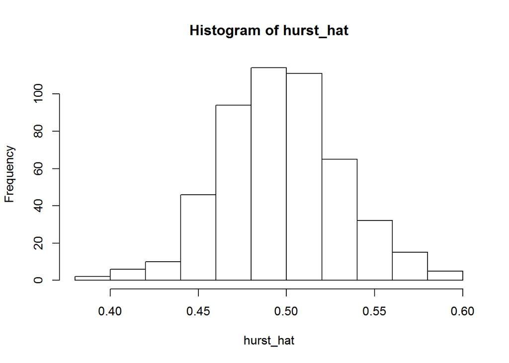

```r
mu <- mean(lretSP500Index)
sigma <- sd(lretSP500Index)
hurst_hat=array(dim=500)
for (i in 1:500){
X1 <- rnorm(length(lretSP500Index),mean=mu,sd=sigma)
hurst_hat[i]=hurst(X1)$Hal
}
hist(hurst_hat)
```

From the empirical distribution of our estimates, we do not reject the null hypothesis because it is obvious that the estimates(0.5010563) falls into the 95% confidence interval(which is [0.43,0.56] to be shown later). We believe that the process of accumulatd log returns of SP500 since 2000 is Brownian motion(daily log return are independent). How about taking a look at how the Hurst parameter changes since 2000? The x-axis represents the tranding day since Jan 3rd, 2000. The gap results from that the beginning 1000 days are used to calculate the estimate.

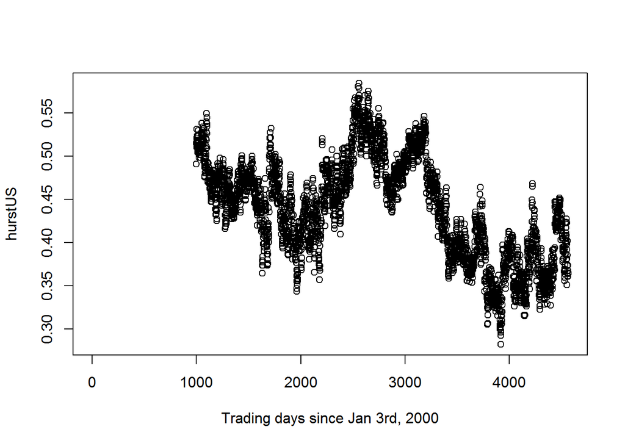

```r
hurstUS=array(NA,length(lretSP500Index))
for(i in 1000:(length(lretSP500Index))){
  hurstUS[i]=hurst(lretSP500Index[(i-1000):i],display = FALSE)$Hal
}
plot(hurstUS,xlab='Trading days since Jan 3rd, 2000')
```

```r
quantile(hurst_hat,0.025)
```

```
##      2.5%
## 0.4340515
```

```r
quantile(hurst_hat,0.975)
```

```
##    97.5%
## 0.564916
```

# 4 Futures as Proxy and Regression with ARMA Errors Model

## 4.1 Introduction of Futures Data

The “S&P500CMEContinuousPriceHistory” is the historical daily last price of S&P Futures. We can see from the graph that it is almost the same as S&P Index because of the financial equation covered in next subsection.

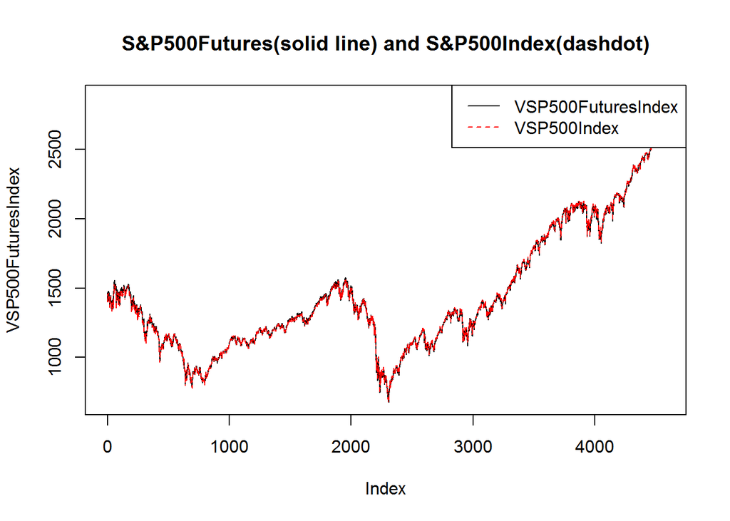

```r
plot(VSP500FuturesIndex,type="line",main = "S&P500Futures(solid line) and S&P500Index(dashdot)")
lines(VSP500Index,col="red",lty = "dotdash")
legend("topright",expression("VSP500FuturesIndex","VSP500Index"),lty=c(1,2),col=c("black","red"))
```

The futures and spot are quite close with each other and we can observe some spread. Let us focus on their relationship first.

## 4.2 Spot–future Parity

Spot–future parity (or spot-futures parity) is a parity condition whereby, if an asset can be purchased today and held until the exercise of a futures contract, the value of the future should equal the current spot price adjusted for the cost of money.
$$F=Se^{rT}$$
F, S represent the cost of the index on the futures market and the spot market(Index ETF fund), respectively. e is the mathematical constant for the base of the natural logarithm. r is the applicable interest rate (for arbitrage, the cost of borrowing), stated at the continuous compounding rate. T is the time period applicable (fraction of a year) to delivery of the forward contract. Note that the formulation assumes that transaction costs are insignificant.

## 4.3 Regression with ARMA

Regress the index with the futures to see how they are linearly related given maturity T fixed.

```r
SpotFuturesArbitrage <- lm(VSP500Index~VSP500FuturesIndex)
summary(SpotFuturesArbitrage)
```

```
##
## Call:
## lm(formula = VSP500Index ~ VSP500FuturesIndex)
##
## Residuals:
##     Min      1Q  Median      3Q     Max
## -28.462  -2.416   0.963   3.739  32.285
##
## Coefficients:
##                      Estimate Std. Error t value Pr(>|t|)
## (Intercept)        -3.8866777  0.2947919  -13.18   <2e-16 ***
## VSP500FuturesIndex  1.0028347  0.0001949 5144.25   <2e-16 ***
## ---
## Signif. codes:  0 '***' 0.001 '**' 0.01 '*' 0.05 '.' 0.1 ' ' 1
##
## Residual standard error: 5.827 on 4563 degrees of freedom
## Multiple R-squared:  0.9998, Adjusted R-squared:  0.9998
## F-statistic: 2.646e+07 on 1 and 4563 DF,  p-value: < 2.2e-16
```

The linear relationship is so obvious. Let us regard the futures price as proxy and do a regression with ARMA errors model.
**linear regression with ARMA errors**
$$\phi(B) ((Index)_n-\beta*(Futures)_{n}-\mu) = \psi(B) \epsilon_n$$
where $\{\epsilon_n\}$ is a white noise process. $B$ is the backshift operator. $\mu$ is the mean. $\phi(x)$ and $\psi(x)$ are the ARMA polynomials.
$$\phi(x) = 1-\phi_1 x -\phi_2 x^2 -\dots -\phi_p x^p.\\\psi(x) = 1+\psi_1 x +\psi_2 x^2 + \dots +\psi_q x^q,$$

```r
aic_table <- function(data,P,Q,xreg=NULL){
  table <- matrix(NA,(P+1),(Q+1))
  for(p in 0:P) {
    for(q in 0:Q) {
      table[p+1,q+1] <- arima(data,order=c(p,0,q),xreg=xreg)$aic
    }
  }
  dimnames(table) <- list(paste("<b> AR",0:P, "</b>", sep=""),paste("MA",0:Q,sep=""))
  table
}
SpotFuturesArbitrage_aic_table <- aic_table(VSP500Index,2,2,xreg=VSP500FuturesIndex)
require(knitr)
kable(SpotFuturesArbitrage_aic_table,digits=2)
```

|  | MA0 | MA1 | MA2 |
| --- | --- | --- | --- |
| **AR0** | 29050.09 | 26737.52 | 25669.09 |
| **AR1** | 24243.47 | 23015.92 | 23077.43 |
| **AR2** | 23550.34 | 23065.92 | 23036.62 |

Further attempts of increasing P and Q gives me Warning:possible convergence problem: optim gave code = 1possible convergence problem: optim gave code = 1 possible convergence problem: optim gave code = 1 Error in arima(data, order = c(p, 0, q), xreg = xreg) : non-stationary AR part from CSS.

In fact those two series are both unstationary series as we can see on the graph before. We believe that there exists a spurious regression. From the financial perspective and regression result, we know that they have long-term equilibrium. The residual of their regression represents the contango or backwardation of the futures relative to spot index. We want to take a glance at the spectrum of the residual.

## 4.4 Spectrum of Spot-Futures Spread

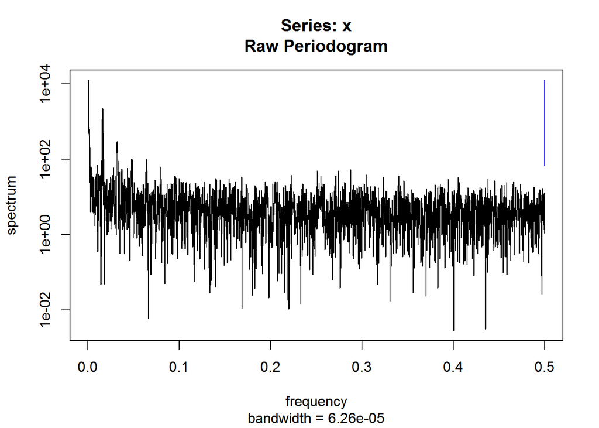

```r
spectrum(SpotFuturesArbitrage$residuals)
```

The cycles are not obvious, let us smooth the data.

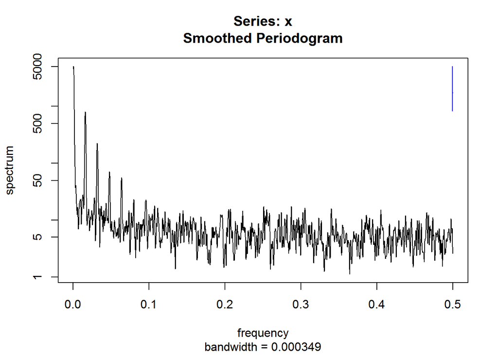

```r
spectrum(SpotFuturesArbitrage$residuals,spans=c(3,5,3))
```

# 5 Financial Assets with Autocorrelated Returns

Are all financial assets have almost independent daily returns? Let’s look at a kind of fixed income asset, Shanghai Stock Exchange reverse repurchase product. The daily return, Shanghai Stock Exchange reverse repurchase interest rate GC001(retRevRepo) having ACF as following graph.

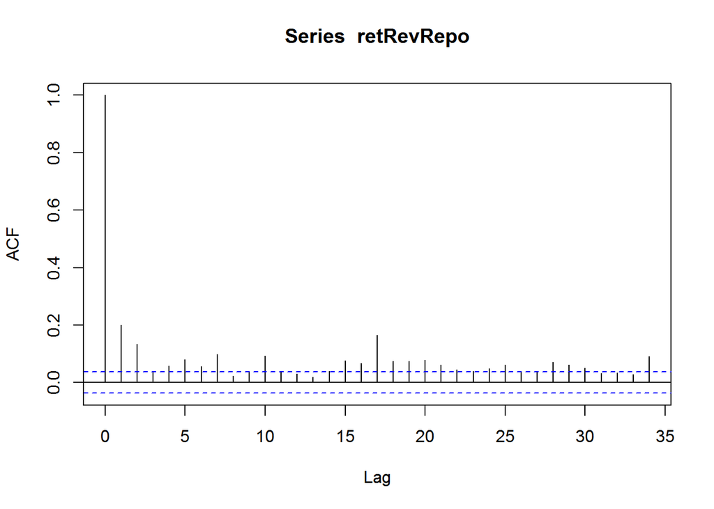

```r
acf(retRevRepo)
```

The daily returns of reverse repurchase product are highly correlated and have a quite long tail on the ACF. Let us use ARMA model specified before again and check the AIC table to determine the best model.

## 5.1 Model Selection

```r
retRevRepo_aic_table <- aic_table(retRevRepo,7,7)
require(knitr)
kable(retRevRepo_aic_table,digits=2)
```

|  | MA0 | MA1 | MA2 | MA3 | MA4 | MA5 | MA6 | MA7 |
| --- | --- | --- | --- | --- | --- | --- | --- | --- |
| **AR0** | -11083.06 | -11175.70 | -11219.01 | -11217.58 | -11217.98 | -11222.35 | -11220.96 | -11244.31 |
| **AR1** | -11197.28 | -11224.28 | -11281.66 | -11297.99 | -11298.47 | -11296.68 | -11294.88 | -11242.35 |
| **AR2** | -11222.36 | -11220.48 | -11220.34 | -11297.74 | -11296.14 | -11299.42 | -11297.48 | -11240.40 |
| **AR3** | -11220.40 | -11218.50 | -11295.09 | -11296.66 | -11314.22 | -11317.62 | -11315.83 | -11299.34 |
| **AR4** | -11222.80 | -11298.08 | -11296.07 | -11317.79 | -11293.33 | -11314.68 | -11314.24 | -11313.07 |
| **AR5** | -11232.20 | -11296.15 | -11297.56 | -11316.54 | -11313.92 | -11314.94 | -11325.92 | -11325.74 |
| **AR6** | -11231.50 | -11295.54 | -11296.77 | -11316.13 | -11314.00 | -11327.37 | -11325.65 | -11323.71 |
| **AR7** | -11244.17 | -11243.07 | -11252.07 | -11314.44 | -11301.26 | -11325.70 | -11323.34 | -11311.61 |

We choose ARMA(6,5) model because it provides with smallest AIC in a relatively small model.

## 5.2 Test of Seasonality and Diagnostic Analysis

Many investors in the reverse repurchase market believe that there is a monthly seasonality because banks need liquidity at the end of each month, thus leading to higher reerse repurchase interest rate by the increase of demand. We use SARMA model to test this hypothesis based on the previous ARMA coefficients we have got. 21 represents the number of trading days per month. We fit the data with SARMA$(6,5)×(1,0)_{21}$ model
$${\quad\quad\quad}{\phi}(B){\Phi}(B^{21}) ((RetRevRepo))_n-\mu) = {\psi}(B){\Psi}(B^{21}) \epsilon_n$$
where $\{\epsilon_n\}$ is a white noise process and
$$\mu = E[(RetRevRepo)_n]
\\
\phi(x)=1-\phi_1 x-\dots -\phi_6x^6,
\\
\psi(x)=1+\psi_1 x+\dots +\psi_5x^5,
\\
\Phi(x)=1-\Phi_1 x,
\\
\Psi(x)=1.$$
$$H_{0}:\Phi_1=0\\H_{1}:H_{0}\text{ is not true}$$

```r
seasonality_of_RevRepo=arima(retRevRepo,order=c(6,0,5),seasonal=list(order=c(1,0,0),period=21))
SARMA_roots <- polyroot(c(1,-coef(seasonality_of_RevRepo)[c("sar1")]))
seasonality_of_RevRepo
```

```
##
## Call:
## arima(x = retRevRepo, order = c(6, 0, 5), seasonal = list(order = c(1, 0, 0),
##     period = 21))
##
## Coefficients:
##          ar1      ar2     ar3     ar4     ar5      ar6     ma1     ma2
##       0.1043  -0.1369  0.2144  0.0432  0.8850  -0.1259  0.0560  0.2124
## s.e.  0.0383   0.0250  0.0285  0.0328  0.0311   0.0209  0.0336  0.0255
##           ma3      ma4      ma5    sar1  intercept
##       -0.2129  -0.0551  -0.8970  0.0103     0.0278
## s.e.   0.0219   0.0295   0.0277  0.0196     0.0038
##
## sigma^2 estimated as 0.001086:  log likelihood = 5676.84,  aic = -11325.68
```

```r
SARMA_roots
```

```
## [1] 97.03315+0i
```

It is stationary but the coefficient $\Phi_1$ is almost zero and the t-statistics of seasonal AR coefficient $\Phi_1$ is 0.53<1.96. Let us see the profile likelihood.

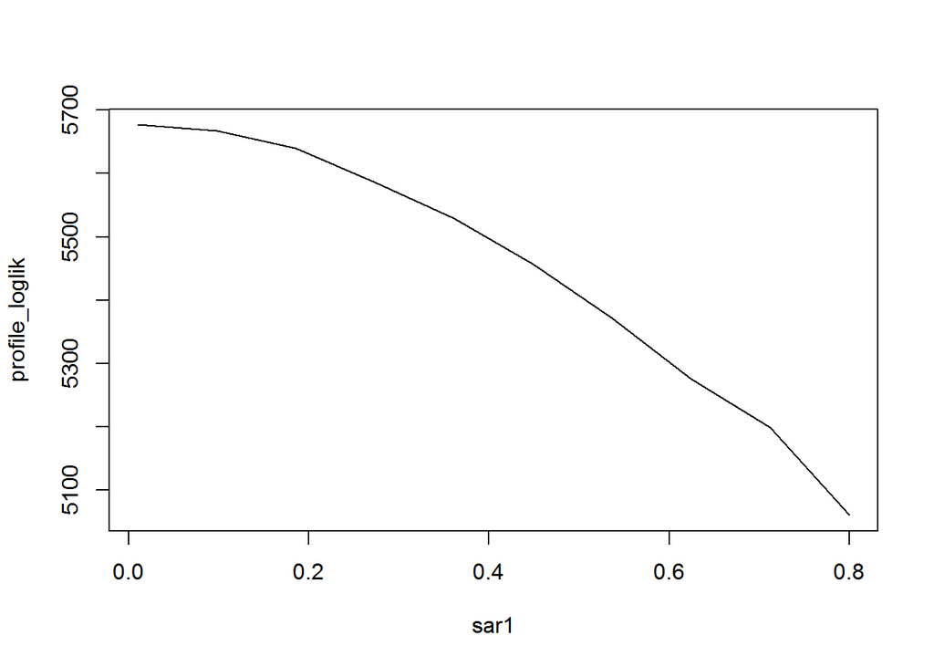

```r
K=10
sar1 <- seq(from=0.01,to=0.8,length=K)
profile_loglik <- rep(NA,K)
for(k in 1:K){
   profile_loglik[k] <- logLik(arima(retRevRepo,order=c(6,0,5),seasonal=list(order=c(1,0,0),period=21),
      fixed=c(NA,NA,NA,NA,NA,NA, NA,NA,NA,NA,NA,sar1[k],NA)))
}
plot(profile_loglik~sar1,ty="l")
```

It seems the loglikelihood is maximized around 0. Let us zoom in to take a look and check the magnitude.

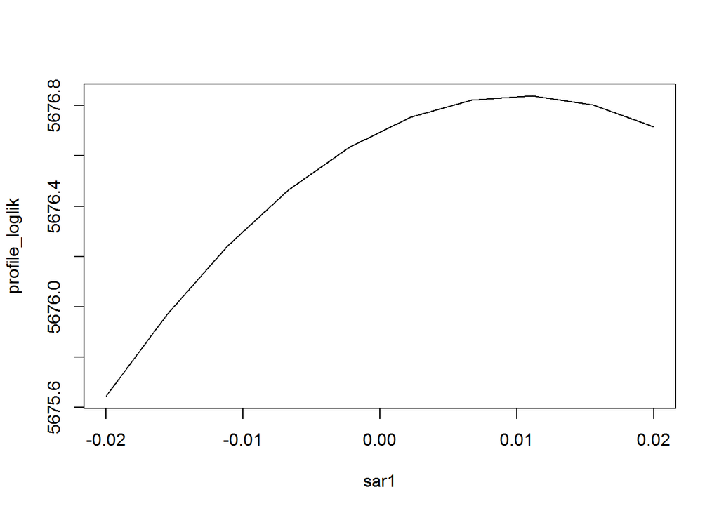

```r
K=10
sar1 <- seq(from=-0.02,to=0.02,length=K)
profile_loglik <- rep(NA,K)
for(k in 1:K){
   profile_loglik[k] <- logLik(arima(retRevRepo,order=c(6,0,5),seasonal=list(order=c(1,0,0),period=21),
      fixed=c(NA,NA,NA,NA,NA,NA, NA,NA,NA,NA,NA,sar1[k],NA)))
}
plot(profile_loglik~sar1,ty="l")
```

From both the confidence interval of $\Phi_1$ and the loglikelihood graph, we can not reject the $H_{0}$ because 5676.8-1.92=5674.88 and the interval contains 0. The one month seasonality of the return of RevRepo may not exist. The phenomenon of increasing of reverse repurchase rate is occasional rather than a significant pattern.

# 6 Estimates of other markets

We apply the hurst function to log returns of other markets to find interesting patterns.

## 6.1 China A-Share Market

```r
CSI300Index=read.csv(file="https://raw.githubusercontent.com/RickYuankangHung/Quant-python/master/CSI300IndexPriceHistory.csv")
HangSengIndex=read.csv(file="https://raw.githubusercontent.com/RickYuankangHung/Quant-python/master/HangSengIndexPriceHistory.csv")
lretCSI300Index=diff(log((array(rev(as.numeric(as.character(CSI300Index$Price)))))))
lretHangSengIndex=diff(log((array(rev(as.numeric(as.character(HangSengIndex$Price)))))))
date=seq(from=1,to=length(lretCSI300Index),by=1)

VCSI300Index=rev(array((as.numeric(as.character(CSI300Index$Price)))))

CSI300FuturesIndex=read.csv(file="https://raw.githubusercontent.com/RickYuankangHung/Quant-python/master/CSI300ContinuousPriceHistory.csv")
VCSI300FuturesIndex=rev(array((as.numeric(as.character(CSI300FuturesIndex$SettlementPrice)))))
```

```r
hurst(lretCSI300Index)
```

```
## $Hal
## [1] 0.6050533
```

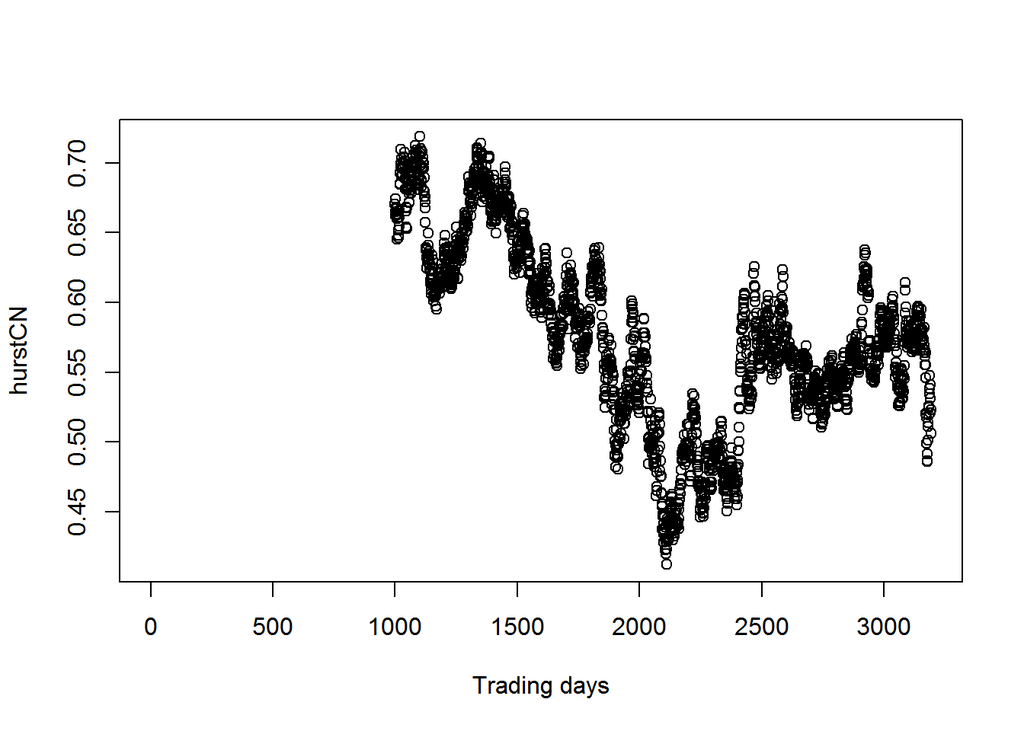

```r
hurstCN=array(NA,length(lretCSI300Index))
for(i in 1000:(length(lretCSI300Index))){
  hurstCN[i]=hurst(lretCSI300Index[(i-1000):i],display = FALSE)$Hal
}
plot(hurstCN,xlab='Trading days')
```

We can see that the estimated empirical Hurst parameter is 0.6050533 which is much greater than Brownian motion. From the confidence interval derived from a bootstrap, we believe this is not a Brownian motion and the increments are positively correlated.